# Lecture #7: The Normal Distribution

MATH 321 – Mathematical Statistics I

Torin Quinlivan

tquinlivan@knox.edu

Knox College

October 8, 2026

## The Normal Distribution

A random variable $Y$ is said to have a normal (or Gaussian) probability distribution if and only if, for $\sigma > 0$ and $-\infty < \mu < \infty$, the density function of $Y$ is
$$f_Y(y) = \frac{1}{\sqrt{2 \pi \sigma^2}}\exp\left\{ -\frac{(y - \mu)^2}{2\sigma^2} \right\}, \qquad -\infty < y < \infty.$$

We write
$$Y \sim \text{Normal}(\mu,\, \sigma^2)$$
to say that $Y$ is drawn from a normal distribution with parameters $\mu$ and $\sigma^2$.

## The Support of a Random Variable

The support of a random variable is the set of values where its PMF or PDF is positive: $\{ y : p_Y(y) > 0 \}$ for a discrete random variable, or $\{ y : f_Y(y) > 0 \}$ for a continuous random variable.

In the case of the binomial distribution, the support of $Y$ is $\{ 0, 1, 2, \dots, n \}$.

In the case of the normal distribution, the support of $Y$ is $\mathbb{R}$.

## The Graph of the Normal Distribution

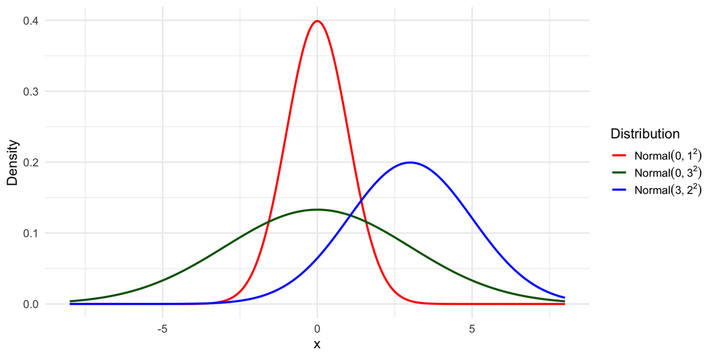

## Facts about Definite Integrals

A function $f$ is even if $f(x) = f(-x)$ for all $x \in \mathbb{R}$.

If $f(x)$ is even, then for any $a > 0$:
$$\int_{-a}^a f(x) \, dx = 2 \int_0^a f(x) \, dx$$

## Facts about Definite Integrals

A function $f$ is odd if $-f(x) = f(-x)$ for all $x \in \mathbb{R}$.

If $f(x)$ is odd, then for any $a > 0$:
$$\int_{-a}^a f(x) \, dx = 0$$
This also holds for $\displaystyle\int_{-\infty}^\infty f(x) \, dx$, provided $\displaystyle\int_{-\infty}^\infty \lvert f(x) \rvert \, dx < \infty$.

## Expected Value and Variance of the Normal Distribution

**Theorem:** If $Y \sim \text{Normal}(\mu, \sigma^2)$, then
$$E[Y] = \mu \quad \text{and} \quad V[Y] = \sigma^2.$$

## Proof of Expected Value of the Normal Distribution

Substitute $u = y - \mu$, so $du = dy$:
$$\begin{aligned}
E[Y] &= \frac{1}{\sqrt{2 \pi \sigma^2}} \int_{-\infty}^\infty y \exp\left\{ -\frac{(y - \mu)^2}{2 \sigma^2} \right\} \, dy \\
&= \frac{1}{\sqrt{2 \pi \sigma^2}} \int_{-\infty}^\infty (u + \mu) \exp\left\{ -\frac{u^2}{2 \sigma^2} \right\} \, du \\
&= \frac{1}{\sqrt{2 \pi \sigma^2}} \int_{-\infty}^\infty u \exp\left\{ -\frac{u^2}{2 \sigma^2} \right\} \, du \\
&\qquad\quad + \frac{1}{\sqrt{2 \pi \sigma^2}} \int_{-\infty}^\infty \mu \exp\left\{ -\frac{u^2}{2 \sigma^2} \right\} \, du \\
&= 0 + \mu \left( \frac{1}{\sqrt{2 \pi \sigma^2}} \int_{-\infty}^\infty \exp\left\{ -\frac{u^2}{2 \sigma^2} \right\} \, du \right) \\
&= \mu.
\end{aligned}$$

## Proof of Expected Value of the Normal Distribution

$$\begin{aligned}
E[Y] &= \frac{1}{\sqrt{2 \pi \sigma^2}} \int_{-\infty}^\infty u \exp\left\{ -\frac{u^2}{2 \sigma^2} \right\} \, du \\
&\qquad\quad + \frac{1}{\sqrt{2 \pi \sigma^2}} \int_{-\infty}^\infty \mu \exp\left\{ -\frac{u^2}{2 \sigma^2} \right\} \, du \\
&= 0 + \mu \left( \frac{1}{\sqrt{2 \pi \sigma^2}} \int_{-\infty}^\infty \exp\left\{ -\frac{u^2}{2 \sigma^2} \right\} \, du \right) \\
&= \mu.
\end{aligned}$$
The first integral is $0$ because the integrand is odd and $\displaystyle\int_{-\infty}^\infty \lvert u \rvert e^{-u^2/(2\sigma^2)} \, du < \infty$.

## Proof of Variance of the Normal Distribution

Substitute $z = \dfrac{y - \mu}{\sigma}$, so $dy = \sigma \, dz$, then integrate by parts:
$$\begin{aligned}
V[Y] &= \frac{1}{\sqrt{2 \pi \sigma^2}} \int_{-\infty}^\infty (y - \mu)^2 \exp\left\{ -\frac{(y - \mu)^2}{2 \sigma^2} \right\} \, dy \\
&= \frac{\sigma^2}{\sqrt{2 \pi}} \int_{-\infty}^\infty z^2 e^{ -\frac{z^2}{2} } \, dz \\
&= \frac{\sigma^2}{\sqrt{2 \pi}} \left( -z e^{-\frac{z^2}{2}} \bigg\rvert_{-\infty}^\infty \right) + \frac{\sigma^2}{\sqrt{2 \pi}} \int_{-\infty}^\infty e^{-\frac{z^2}{2}} \, dz \\
&= 0 + \sigma^2 \left( \frac{1}{\sqrt{2\pi}} \int_{-\infty}^\infty e^{-\frac{z^2}{2}} \, dz \right) \\
&= \sigma^2.
\end{aligned}$$

## The Standard Normal Distribution

The standard Normal (or Gaussian) random variable $Z$ has a PDF
$$f_Z(z) = \frac{1}{\sqrt{2 \pi}} \exp\left\{ -\frac{z^2}{2} \right\}.$$
That is, $Z \sim \text{Normal}(0,1)$ is a Normal random variable with mean $\mu = 0$ and $\sigma^2 = 1$.

## The Standard Normal Distribution

The cumulative distribution function (CDF) of the standard Normal is defined as the function $\Phi(\cdot)$
$$\Phi(z) \overset{def}{=} F_Z(z) = P(Z \le z) = \frac{1}{\sqrt{2 \pi}} \int_{-\infty}^z e^{-\frac{t^2}{2}} \, dt.$$

## CDF of an Arbitrary Normal Distribution

**Theorem (CDF of an arbitrary Normal):**

Let $Y \sim \text{Normal}(\mu, \sigma^2)$. Then
$$F_Y(y) = P(Y \le y) = \Phi\left( \frac{y - \mu}{\sigma} \right)$$

**Examples:**

1. Find $P(Z \le 2.00)$.
2. Let $Y \sim \text{Normal}(3, 4)$. Find $P(Y \le 11)$.

## Properties of Normal Distributions

**Theorem:** Let $Y \sim \text{Normal}(\mu, \sigma^2)$. Then the following results hold:

1. $\Phi(z) = 1 - \Phi(-z)$.
2. $P(Y \ge b) = 1 - \Phi\left( \frac{b - \mu}{\sigma} \right)$.
3. $P(\lvert Y \rvert \ge b) = 1 - \Phi\left( \frac{b - \mu}{\sigma} \right) + \Phi\left( \frac{-b-\mu}{\sigma} \right)$, for $b \ge 0$.

## Normal Distribution Example

Intelligence Quotient (IQ) scores are defined to follow a Normal distribution with a mean of 100 and a standard deviation of 15. Use this information to answer the following questions:

1. Find the probability that a randomly chosen person has an IQ less than 92.
2. Find the probability that a randomly chosen person has an IQ of 120 or greater.
3. Find the probability that a randomly chosen person has an IQ between 83 and 114.

## Skewness and Kurtosis

For a random variable $X$ with PDF $f_X(x)$, define the following moments as:
$$\begin{gather*}
\text{mean:} \quad E[X] \overset{def}{=} \mu, \\[0.3em]
\text{variance:} \quad E[(X - \mu)^2] \overset{def}{=} \sigma^2, \\[0.3em]
\text{skewness:} \quad E\left[ \left( \frac{X - \mu}{\sigma} \right)^3 \right] \overset{def}{=} \gamma, \\[0.3em]
\text{kurtosis:} \quad E\left[ \left( \frac{X - \mu}{\sigma} \right)^4 \right] \overset{def}{=} \kappa.
\end{gather*}$$

## Skewness and Kurtosis

The kurtosis of a distribution measures the “tailedness” of the distribution: how much probability lies in its extreme tails.

We define excess kurtosis to be $\kappa - 3$. Excess kurtosis is easier to understand/interpret than “raw” kurtosis.

The normal distribution has skewness $0$ and excess kurtosis $0$.

## Normal Distribution Example

Intelligence Quotient (IQ) scores are defined to follow a Normal distribution with a mean of 100 and a standard deviation of 15. Use this information to answer the following questions:

4. What IQ score is greater than 40% of people?
5. What IQ score is less than the top 15% of people?
6. What IQ scores are the bounds of the middle 95% of people?

## Percentiles of Probability Distributions

Let $X$ be a continuous random variable with probability density function $f_X$. The median of $X$ is a point $c \in \mathbb{R}$ such that
$$F_X(c) = \int_{-\infty}^c f_X(x) \, dx = \int_c^\infty f_X(x) \, dx.$$

**Theorem:** The median of a random variable $X$ is the point $c$ such that
$$F_X(c) = \frac{1}{2}.$$

## Percentiles of Probability Distributions

What about other percentiles, like the $35^{th}$ percentile?

The $k^{th}$ percentile of a random variable $X$ is the point $c$ such that
$$F_X(c) = \frac{k}{100}.$$

The quantile function is the inverse of the CDF (when $F_X$ is strictly increasing). In general, it is defined as $F_X^{-1}(p) = \inf\{ x : F_X(x) \ge p \}$. These are hard to compute for most distributions, so we tend to use R.

## Percentile Example

A train arrives at the station between 0 and 15 minutes late, distributed uniformly:

1. What is the median number of minutes the train is late?
2. What is the 35<sup>th</sup> percentile of the amount of time the train will be late?

## Normal Distribution Example

Intelligence Quotient (IQ) scores are defined to follow a Normal distribution with a mean of 100 and a standard deviation of 15. Use this information to answer the following questions:

7. Mensa International famously only allows people who score at the 98th percentile or higher on a standardized, supervised IQ test to join. What IQ score must you have to join Mensa?